# Foundations for inference using R

Ziv Shkedy, Hasselt University

# Introduction

This chapter introduces the important ideas in drawing estimates from samples by discussing methods of inference for a population mean, $\mu$, including three widely used tools: point estimates for a population mean, interval estimates that include both a point estimate and a margin of error, and a method for testing scientific hypotheses about $\mu$. The concepts used in this chapter will appear throughout the rest of the book, which discusses inference for other settings. While particular equations or formulas may change to reflect the details of a problem at hand, the fundamental ideas will not.

## R ?

Only basic knowledge in R is required. All the models discussed in the book can be fitted using the {$glm()$function in R. The datasets used for illustrations are available in R and many of them are part of the $bootstrap$ R package. To run the code smoothly, this package need to be installed.

```r
library(bootstrap)
```

## A for loop in R

A for loop in R is a loop in which we repeatedly ask R to do the same action in each step of the loop. For example, suppose that we would like to draw a sample of 10 observations from $N(0,1)$. In R this can be done using the code

```r
x<-rnorm(10,0,1)
```

The sample is

```r
x
```

```
##  [1] -0.87500122  0.67843784  1.82186115  1.86988801 -0.05846540 -0.54219680
##  [7] -2.40616653  0.12293268 -1.03033566 -0.04758924
```

and the sample mean

```r
mx<-mean(x)
mx
```

```
## [1] -0.04666352
```

Suppose that we would like to draw a sample of 10 observations from $N(0,1)$ 1000 times. To do this we can use a ``for loop’’ in the following way:

```r
mx<-c(1:1000)
for(i in 1:1000)
{
x<-rnorm(10,0,1)
mx[i]<-mean(x)
}
```

A histogram of the sample means:

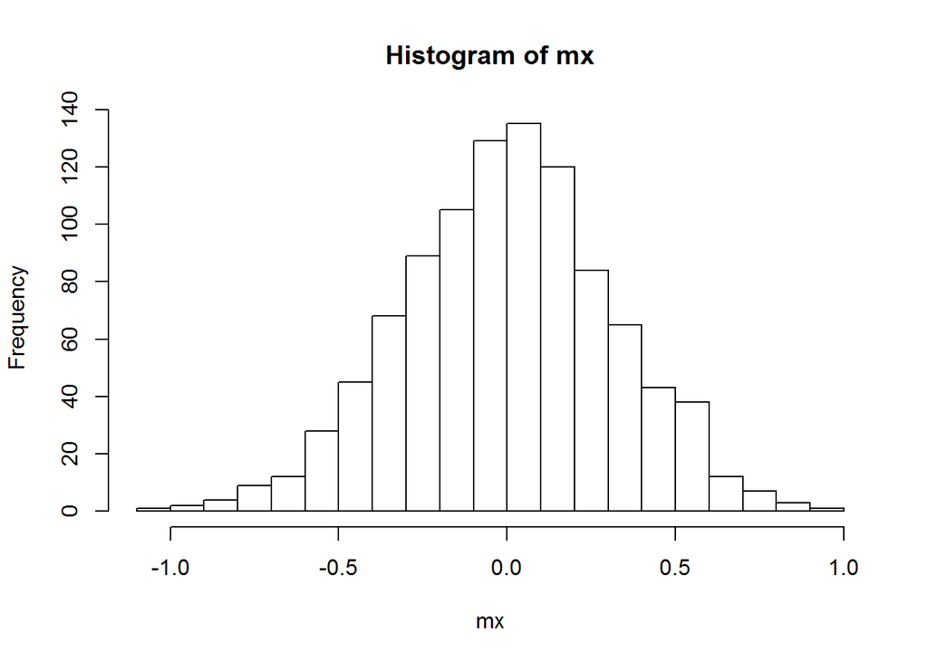

```r
hist(mx,nclass=20)
```

## Just do it

If you did not have a problem to understand the R code above, you will not have any problem to understand the R code that we use to produce all the output for the examples discuss in this book. If you had a difficulty to understand the ``for loop’’ example above you need a short training, at a beginner level, in R.

### YouTube tutorial: the for loop in R

For a short online YouTube introduction by Richard Webster about a for loop in R see [YTBootstrap 1](https://www.youtube.com/watch?v=h987LWDvqlQ).

### R course online

An introductory course for R is able online in the >eR-BioStat website. See [Rcourse](https://github.com/eR-Biostat/Courses/tree/master/Introductory%20Courses/Introduction%20to%20R/Slides).

# Basic concepts: parameters, parameter estimates and variability

## Sampling form a pupulation.

## Variability in estimates

$$\bar{x}_{\text{ozone}} = 42.12$$
In R we can estimate the mean by

```r
x<-na.omit(airquality$Ozone)
length(x)
```

```
## [1] 116
```

```r
MLx<-mean(x)
SDx<-sqrt(var(x))
c(MLx,SDx)
```

```
## [1] 42.12931 32.98788
```

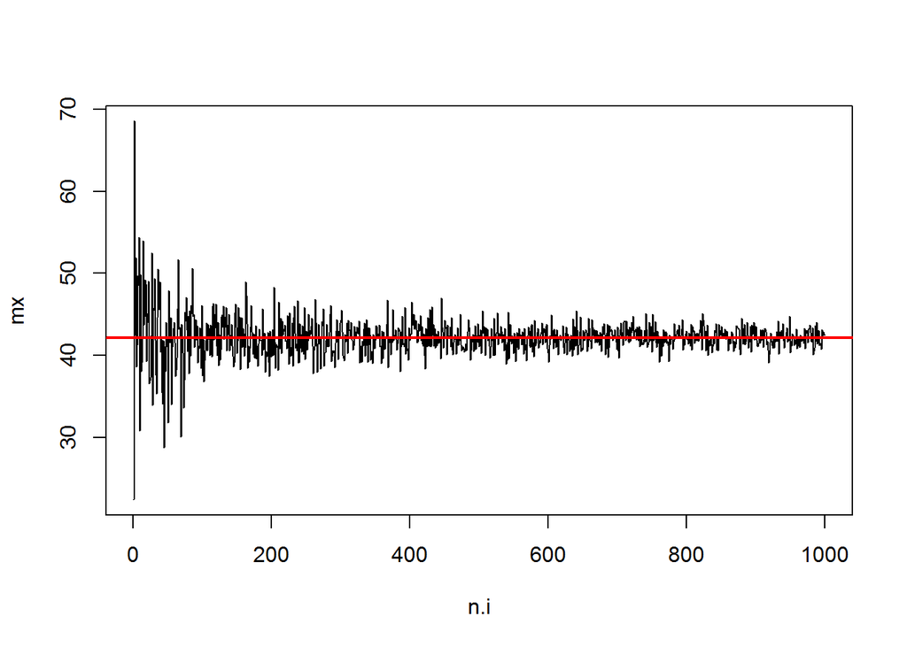

```r
n.i<-c(1:1000)
nsim<-1000
mx<-c(1:nsim)
mu<-42.12
for(i in 1:nsim)
{
x<-rnorm(n.i[i],MLx,SDx)
mx[i]<-mean(x)
}

plot(n.i,mx,type="l")
abline(MLx,0,lwd=2,col=2)
```

As sample size increases, the fluctuations around the population mean decrease; in other words, as sample size increases, the sample mean becomes less variable and provides a more reliable estimate of the population mean.

### The sampling distribution for the mean

#### Definition: Sampling distribution

The sampling distribution is the distribution of the point estimates based on samples of a fixed size from a certain population. It is useful to think of a particular point estimate as being drawn from a sampling distribution.

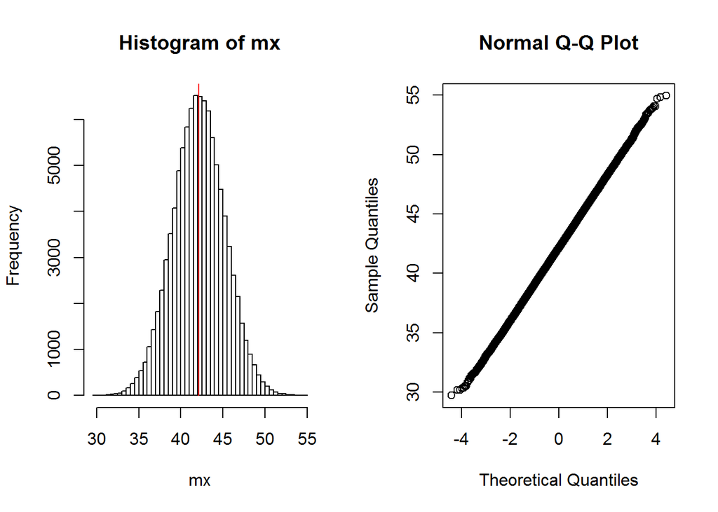

```r
nsim<-100000
mx<-c(1:nsim)
for(i in 1:nsim)
{
x<-rnorm(116,MLx,SDx)
mx[i]<-mean(x)
}

par(mfrow=c(1,2))
hist(mx,nclass=50)
lines(c(MLx,MLx),c(0,10000),col=2)
qqnorm(mx)
```